# The evolution of diverse antimicrobial responses in vancomycin-intermediate Staphylococcus aureus and its therapeutic implications

Dena Crozier, Jason Gray, and Kyle Card

## Prerequisites

Clear current environment

Load packages for use

```r
library(tidyverse)
library(proxy)
library(knitr)
library(colorspace)
library(cowplot)
```

# Experimental evolution under vancomycin selection

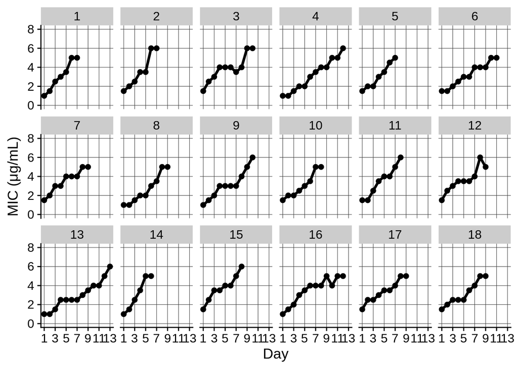

```r
vancomycin_MICs <- read_csv("vancomycin_MICs.csv")
# In the MIC column, replace all "-" with "NA"
vancomycin_MICs$MIC <- vancomycin_MICs$MIC %>%
    str_replace_all("-", "NA") %>%
    as.numeric()
# Remove all rows with NA values in the MIC column
vancomycin_MICs <- vancomycin_MICs %>%
    filter(!is.na(MIC))

# Plot of vancomycin MICs over time
vancomycin_MICs_plot <- vancomycin_MICs %>%
    ggplot(aes(x = day, y = MIC)) +
        geom_line(linewidth = 1.2) +
        geom_point(size = 2) +
        facet_wrap(~ population, nrow = 3, ncol = 6) +
        scale_x_continuous(
            breaks = seq(1,14,2)) +
        scale_y_continuous(
            limits = c(0, 8),
            breaks = seq(0,8,2)) +
        xlab("Day") +
        ylab(expression("MIC (\u03BCg/mL)")) +
        theme_cowplot() +
        theme(panel.grid.major = element_line(color = "#3a3a3a", linewidth = 0.2))

vancomycin_MICs_plot
```

```r
#ggsave("vancomycin_MICs_plot.png", vancomycin_MICs_plot, path = "Figures", device = "png", width = 14, height = 8, units = "in")
```

# Collateral responses analysis

Data report the minimum inhibitory concentrations (MICs) of 8 antibiotics (cefazolin, clindamycin, daptomycin, gentamycin, meropenem, nafcillin, trimethoprim-sulfamethoxazole, and vancomycin) on the MSSA ancestral clone ATCC 29213 and evolved vancomycin-intermediate populations.

```r
collateral_MICs <- read_csv("collateral_drug_MICs.csv")
```

```r
EstimateCR <- function(dat) {
    # This function takes a data frame of MICs and calculates drug response values
    # for each evolved population relative to the ancestral population.
    ancestor_frame <- dat %>%
        filter(population == "Ancestor")

    evolved_frame <- dat %>%
        filter(population != "Ancestor")

    CR_values <- c()

    # This code chunk iterates through the unique paired_IDs in the evolved_frame and
    # filters the ancestor_frame and evolved_frame for the paired_ID. The MIC values
    # for the ancestor and evolved populations are then used to calculate the collateral
    # response value for each evolved population. The collateral response values are
    # then appended to the CR_values vector.
    for (i in unique(evolved_frame$paired_ID)) {
        ancestor_value <- ancestor_frame %>%
            filter(paired_ID == i) %>%
            pull(MIC)

        evolved_subframe <- evolved_frame %>%
            filter(paired_ID == i)

        for (j in 1:nrow(evolved_subframe)) {
            evolved_value  <- evolved_subframe[j,] %>%
                pull(MIC)

                CR_values <- c(CR_values, log2(evolved_value / ancestor_value))
        }
    }

    # Creates a tibble of collateral response values
    CR_col <- tibble(CR = CR_values)
    CR_df  <- bind_cols(evolved_frame, CR_col)

    # Removed paired_ID column from CR_df
    CR_df <- CR_df %>%
        select(-paired_ID)

    return(CR_df)
}

drug_responses <- EstimateCR(collateral_MICs)

head(drug_responses)
```

| population | replicate | antibiotic | MIC | CR |
| --- | --- | --- | --- | --- |
| 1 | 1 | CFZ | 0.25 | -0.5849625 |
| 1 | 2 | CFZ | 0.25 | -0.5849625 |
| 1 | 3 | CFZ | 0.25 | -0.5849625 |
| 2 | 1 | CFZ | 0.50 | 0.4150375 |
| 2 | 2 | CFZ | 0.50 | 0.4150375 |
| 2 | 3 | CFZ | 0.50 | 0.4150375 |

```r
# Summary statistics function
SummaryStats <- function(dat) {
    summary_stats <- dat  %>%
        group_by(antibiotic, population) %>%
        summarize(mean_MIC = mean(MIC),
            mean_CR = mean(CR))

    return(summary_stats)
        }

summary_stats <- SummaryStats(drug_responses)
# Remove vancomycin rows
summary_stats <- summary_stats %>%
    filter(antibiotic != "VAN")

# Create a new column called "state" in the summary_stats data frame. Populate this column with "-1", "0", or " 1" if the mean collateral response
# value is less than, equal to, or greater than 0.

summary_stats$state <- ifelse(summary_stats$mean_CR < 0, "-1", ifelse(summary_stats$mean_CR == 0, "0", "1"))

head(summary_stats)
```

| antibiotic | population | mean_MIC | mean_CR | state |
| --- | --- | --- | --- | --- |
| CFZ | 1 | 0.2500000 | -0.5849625 | -1 |
| CFZ | 10 | 0.5000000 | 0.1383458 | 1 |
| CFZ | 11 | 0.5000000 | 0.0000000 | 0 |
| CFZ | 12 | 0.5833333 | 0.3333333 | 1 |
| CFZ | 13 | 0.7500000 | 1.0000000 | 1 |
| CFZ | 14 | 0.5000000 | 0.4150375 | 1 |

```r
# Mann-Whitney U test function
MWTest <- function(dat, ab){
    ancestor_df <- dat %>%
        filter(population == "Ancestor" & antibiotic == ab) %>%
        # Remove the replicate and paired_ID columns
        select(-replicate, -paired_ID)

    evolved_df  <- dat %>%
    # Remove the ancestor rows from the dat data frame
        filter(population != "Ancestor" & antibiotic == ab) %>%
        group_by(population) %>%
        # Calculate the mean MIC for each evolved population
        summarize(MIC = mean(MIC)) %>%
        # Relabel all entries in the "population" column to "Evolved"
        mutate(population = ifelse(population == "Ancestor", "Ancestor", "Evolved"))

    # Bind the antibiotic_df and ancestor_df objects
    bound_df <- bind_rows(evolved_df, ancestor_df)

    # Perform Mann Whitney U test comparing the MICs of the ancestor and evolved populations
    MW_test <- wilcox.test(MIC ~ population,
                    data = bound_df,
                    paired = FALSE,
                    exact = FALSE,
                    correct = FALSE,
                    alternative = "two.sided")
}

ab_vec <- unique(summary_stats$antibiotic)

MWStats <- map(ab_vec, ~MWTest(collateral_MICs, ab = .x))

head(MWStats)
```

```
[[1]]

    Wilcoxon rank sum test

data:  MIC by population
W = 55, p-value = 0.3321
alternative hypothesis: true location shift is not equal to 0


[[2]]

    Wilcoxon rank sum test

data:  MIC by population
W = 108, p-value = 0.01754
alternative hypothesis: true location shift is not equal to 0


[[3]]

    Wilcoxon rank sum test

data:  MIC by population
W = 4, p-value = 0.0001314
alternative hypothesis: true location shift is not equal to 0


[[4]]

    Wilcoxon rank sum test

data:  MIC by population
W = 97.5, p-value = 0.1506
alternative hypothesis: true location shift is not equal to 0


[[5]]

    Wilcoxon rank sum test

data:  MIC by population
W = 84, p-value = 0.4946
alternative hypothesis: true location shift is not equal to 0


[[6]]

    Wilcoxon rank sum test

data:  MIC by population
W = 96.5, p-value = 0.156
alternative hypothesis: true location shift is not equal to 0
```

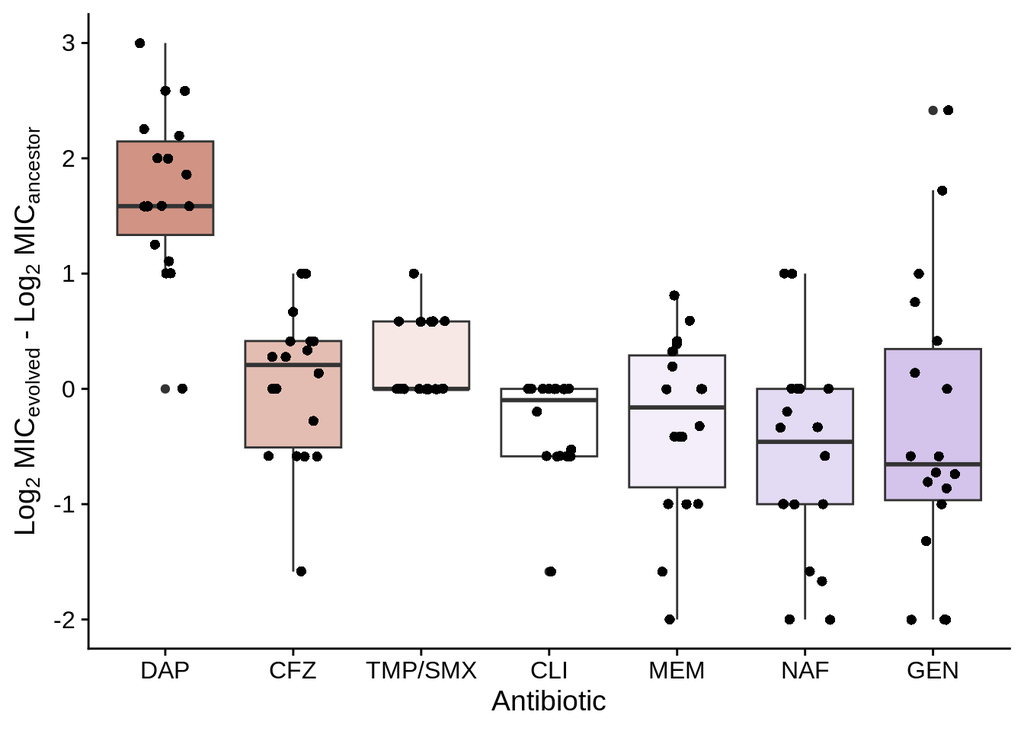

```r
# Plots
# Factor antibiotics by order of decreasing median collateral response
antibiotic_factor <- summary_stats %>%
    group_by(antibiotic) %>%
    summarize(med = median(mean_CR)) %>%
    arrange(desc(med)) %>%
    pull(antibiotic)

summary_stats$antibiotic <- factor(summary_stats$antibiotic, levels = as.factor(antibiotic_factor))

CR_boxplot <- summary_stats %>%
    ggplot(aes(x = antibiotic, y = mean_CR, fill = antibiotic)) +
        geom_boxplot() +
        geom_jitter(shape = 16,
            position = position_jitter(0.2),
            size = 2) +
        xlab("Antibiotic") +
        ylab(expression("Log"[2]~"MIC"["evolved"]~"-"~"Log"[2]~"MIC"["ancestor"])) +
        scale_fill_manual(values = c("#D09384", "#E4BDB2", "#F7E8E6", "#FFFFFF",
            "#F3EEF9", "#E3DAF3", "#D4C3EA", "#CAB7E6")) +
        theme_cowplot() +
        theme(legend.position = "none",
            plot.background = element_rect(fill = "white")
        )

CR_boxplot
```

```r
# ggsave("CR_boxplot.png", CR_boxplot, path = "Figures", device = "png", width = 10, height = 8, units = "in")
```

```r
# For each antibiotic in the summary_stats data frame, calculate the median collateral response values using the mean_CR column.
# Then initialize a counter (L) to zero and increment it by a fraction (1 / total number of populations) for each mean_CR value that is in concordance with the median.

# This code chunk iterates through the unique antibiotics in the summary_stats data frame and calculates the probability of a population exhibiting a drug response.
# The probability of a population exhibiting a drug response is defined as the fraction of evolved populations that have a collateral response value that has the same sign as the median collateral response value.
# The probability of a population exhibiting a drug response is calculated for each antibiotic and stored in the prob_vec vector.
Likelihood <- function(dat) {
    prob_vec <- c()

    median_df <- dat %>%
        group_by(antibiotic) %>%
        summarize(median = median(mean_CR))

for (i in unique(dat$antibiotic)) {
    L <- 0

    ab_frame <- dat %>%
        filter(antibiotic == i)

    med_CR <- ab_frame %>%
        pull(mean_CR) %>%
        median()

    for (j in ab_frame$mean_CR) {
        if (sign(j) == sign(med_CR)) {
            L <- L + (1 / nrow(ab_frame))
        }
    }
    prob_vec <- c(prob_vec, L)
    }

    probability_df <- tibble(antibiotic = unique(dat$antibiotic),
        probability = prob_vec)

    # Join the median_df and probability_df objects by antibiotic
    df <- median_df %>%
        left_join(probability_df, by = "antibiotic")

    return(df)
}

likelihood_df <- Likelihood(summary_stats)
```

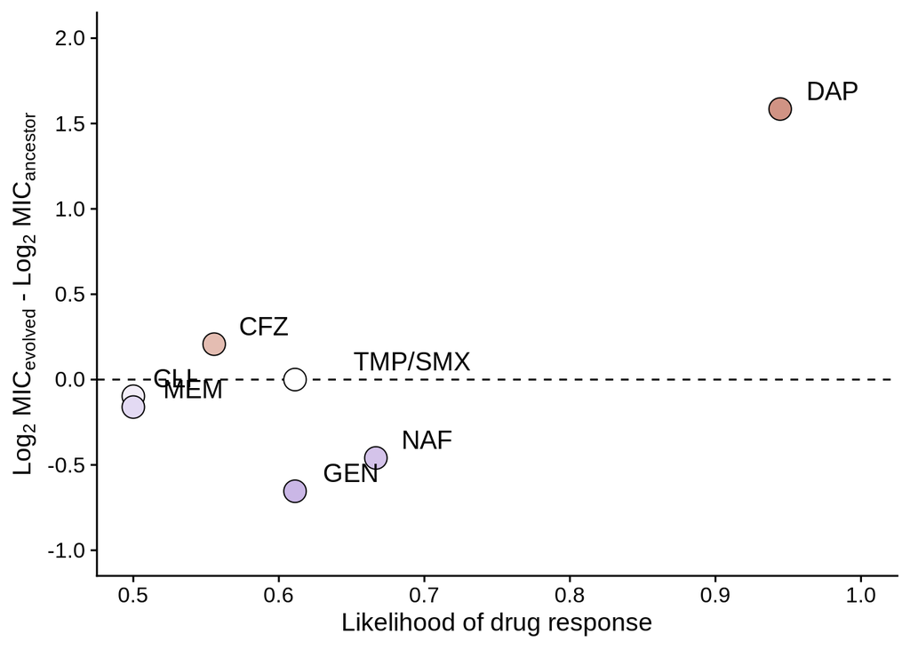

```r
likelihood_plot <- likelihood_df %>%
    ggplot(aes(x = probability, y = median)) +
        geom_hline(yintercept = 0, linetype = "dashed") +
        geom_point(size = 5.5,
            fill = c("#D09384", "#E4BDB2", "#FFFFFF",
            "#F3EEF9", "#E3DAF3", "#D4C3EA", "#CAB7E6"),
            pch = 21) +
        # Label each point with its corresponding antibiotic
        geom_text(aes(label = antibiotic),
            hjust = -0.5,
            vjust = -0.5,
            size = 5) +
        scale_x_continuous(
            limits = c(0.5, 1),
            breaks = seq(0.5, 1, 0.1)) +
        scale_y_continuous(
            limits = c(-1, 2),
            breaks = seq(-1, 2, 0.5)) +
        xlab("Likelihood of drug response") +
        ylab(expression("Log"[2]~"MIC"["evolved"]~"-"~"Log"[2]~"MIC"["ancestor"])) +
        theme_cowplot() +
        theme(legend.position = "none",
            plot.background = element_rect(fill = "white"))

likelihood_plot
```

```r
#ggsave("likelihood_plot.png", likelihood_plot, path = "Figures", device = "png", width = 10, height = 8, units = "in")
```

# Curation of *breseq* results

We amended the *breseq* results by manually changing the gene entry for **S1, S2, S3, S4, S5, S11, and S18** from *LNEJMEBC_00080* to *liaF*. We used the ATCC 29213 reference GenBank file in the *breseq* pipeline and this file has this gene annotated as *LNEJMEBC_00080*. We BLASTed the sequence against the ATCC 23235 reference genome to find the proper *liaF* annotation and its associated function. We did the same for **S3** by changing *LNEJMEBC_00415* to *nfeD* and *LNEJMEBC_00416* to *floA*; **S4, S5, S6, S7, and S16** by changing *LNEJMEBC_01861* to *yycH*; **S5** by changing *LNEJMEBC_00966* to *terC*; **S5, S6, and S7** by changing *LNEJMEBC_01441* to *rrf*; **S7** by changing *LNEJMEBC_00554* to *ebh*; **S9** by changing *LNEJMEBC_02663* to *hxlA*; **S11** by changing *LNEJMEBC_01370* to *thrE*; and **S14** by changing *LNEJMEBC_00567* to *yozE*.

```r
mutations <- read_csv("curated_mutations.csv")
```

# Genomic parallelism

This code chunk takes the curated list of mutations and generates a binary matrix representing the gene-level mutations in each evolutionary replicate. We use this data frame for subsequent analyses and to represent the mutations in the heatmap figure.

```r
# Filter the mutations object by the presence of qualifying mutations.
qualifying_mutations <- mutations %>%
    filter(qualifying_mutation == 1)

# Sorts the genes with qualifying_mutations by number of hits and creates a vector
genes <- qualifying_mutations %>%
    group_by(gene) %>%
    summarize(hits = n()) %>%
    arrange(desc(hits)) %>%
    pull(gene)

# Creates a vector of the unique sample designations in the qualifying_mutations object
populations <- unique(qualifying_mutations$population)

# Creates a binary matrix with the number of rows equal to the number of samples, and
# the number of columns equal to the number of genes in the mutations object and populates the matrix with 0s.
binary_mat <- data.frame(matrix(0, nrow = length(populations), ncol = length(genes)))
colnames(binary_mat) <- genes
rownames(binary_mat) <- populations

# Use the qualifying_mutations object to populate the binary_df object.
# This code chunk iterates through the curated_mutations_df and populates the binary_df with a 1
# if a mutation is present in a given gene / lineage combination

for (i in seq_len(nrow(qualifying_mutations))) {
    binary_mat[qualifying_mutations$population[i], qualifying_mutations$gene[i]] <- 1
}
```

We quantified the extent of parallelism in genome evolution among 18 resistant mutants evolved from the same *S. aureus* ATCC 29213 ancestral strain under increasing vancomycin selection. Following Deatherage et al. 2017 and Card et al. 2021, we included only those “qualifying” mutations that unambiguously impact a single gene, including nonsynonymous point mutations and small indels in genes or within 150 bp upstream of the start of a gene and large deletions if at least one of the affected genes was also found to be mutated in another population. We exclude synonymous mutations and mutations within multicopy elements (e.g., ribosomal RNA operons) that may result from gene conversions but cannot be fully resolved using short-read sequencing data. A total of *88* mutations qualify based upon these criteria.

We estimate Dice’s coefficient of similarity, *S*, for each pair of evolved populations, where
$$S = \frac{2|X \cap Y|}{|X|+|Y|}$$
$|X|$ and $|Y|$ are the sets of genes with mutations in two evolved populations, and $|X \cap Y|$ is the set of genes with mutations in both populations. *S* therefore ranges from 0, when the pair share no mutations in common, to 1, when both have mutations in exactly the same set of genes (Deatherage et al., 2017; Card et al. 2021).

```r
AvgSimilarity <- function(dat) {
    # Computes similarity coefficient for all possible replicate pairs.
    # Populates a matrix with these values
    pwise_simil_matrix <- as.matrix(
        simil(
            dat,
            method = "Dice",
            by_rows = TRUE,
            upper = TRUE,
            diag = TRUE)
    )

    # All values above (and including) the matrix diagonal are converted to
    # NA to ease downstream wrangling
    pwise_simil_matrix[upper.tri(pwise_simil_matrix)] <- NA

    # Converted matrix to a data frame for analysis. NA values above
    # (and including) the matrix diagonal are incorporated into the newly
    # formed dataframe. This piece of code drops the rows contanining NA,
    # effectively retaining only those values *below* the matrix diagonal
    pwise_simil_df <- as.data.frame.table(
        pwise_simil_matrix, responseName = "value") %>%
        rename(population_1 = Var1, population_2 = Var2) %>%
        drop_na()

    # Computes the mean similarity coefficient for all possible replicate pairs
    avg_similarity <- mean(pwise_simil_df$value)

    return(avg_similarity)
}
```

```r
simil_score <- AvgSimilarity(binary_mat)

simil_score
```

```
[1] 0.1102808
```

The average similarity coefficient among all possible replicate pairs is **0.11**. In other words, two populations that independently evolved under vancomycin selection had on average 11% of their mutated genes in common. However, this analysis does not consider the probability that a gene will be mutated more than once across independent populations (i.e., in parallel). To address this issue, we estimate this probability by sampling with replacement a gene *n* times, given a genome of *N* genes. In this calculation, we assume that each gene has equal length and uniformity of mutation rate across the genome (Caballero et al. (2015)).

```r
ParallelProb <- function(dat) {
    # Number of coding sequences (CDSs) in the ATCC 29213 genome (ATCC Genome Portal).
    N <- 2586

    # Creates a data frame with the genes that have more than one mutation and the
    # probability of a gene being mutated more than once across independent populations
    gene_prob <- dat %>%
        group_by(gene) %>%
        summarize(
            num_populations = n_distinct(population),
            gene_prob = (1 / N)^(num_populations - 1)) %>%
        filter(num_populations > 1)

    return(gene_prob)
}
```

```r
parallel_prob <- ParallelProb(qualifying_mutations)

parallel_prob
```

| gene | num_populations | gene_prob |
| --- | --- | --- |
| atl1 | 5 | 2.236073e-14 |
| liaF | 7 | 3.343712e-21 |
| rpoB | 4 | 5.782484e-11 |
| rpoC | 2 | 3.866976e-04 |
| rpsU | 5 | 2.236073e-14 |
| srrA | 2 | 3.866976e-04 |
| stp | 2 | 3.866976e-04 |
| vraS | 6 | 8.646839e-18 |
| walK | 3 | 1.495350e-07 |
| yycH | 5 | 2.236073e-14 |

Heatmap of all qualifying mutations in the sequenced genomes

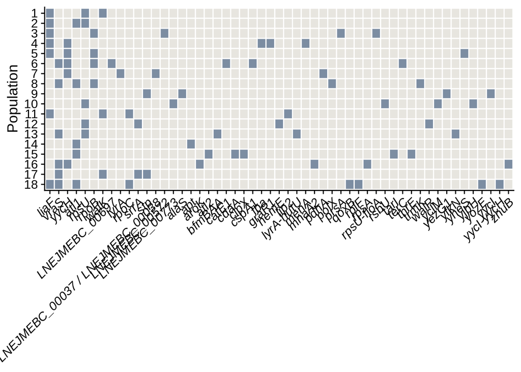

```r
mutation_heatmap <- binary_mat %>%
    # Add a column to the binary_df object with the population designations
    mutate(population = populations) %>%
    # Move the populations column to the front of the binary_df object
    select(population, everything()) %>%
    # Convert the binary_df object to long format with population, gene, and presence columns
    pivot_longer(
        cols = -population,
        names_to = "gene",
        values_to = "presence") %>%
    # Converts the numeric data to catagorical variables to use a discrete colorscale in ggplot2
    mutate(presence = ifelse(presence == 0, "no", "yes")) %>%

    # Create heatmap with genes on the x-axis and populations on the y-axis
    ggplot(aes(x = gene, y = factor(population, level = populations), fill = presence)) +
        geom_tile(color = "white",
            linewidth = 0.5) +
        #scale_x_discrete(limits = rev(replicate_names_vec)) +
        scale_x_discrete(limits = genes) +
        # Reverse the order of the y-axis
        scale_y_discrete(limits = rev) +
        scale_fill_manual(breaks = c("no", "yes"),
            values = c("#E7E5DF", "#7C8DA2")) +
        ylab("Population") +
        theme_cowplot() +
        theme(axis.title.x = element_blank(),
            axis.text.x = element_text(face = "italic",
                angle = 45,
                hjust = 1,
                vjust = 1),
            legend.position = "none")

mutation_heatmap
```

```r
#ggsave("mutation_heatmap.png", mutation_heatmap, path = "Figures", device = "png", width = 15, height = 8, units = "in")
```